# Análisis de Minería de Datos - Detección de Estrés

# 6. Contraste de hipótesis (estadística)

## 6.1. Fumar y Calidad del Sueño

**Hipótesis:**

- H₀: No hay diferencia en la calidad del sueño entre fumadores y no fumadores.
- H₁: Hay una diferencia en la calidad del sueño entre fumadores y no fumadores.

**Test estadístico (Wilcoxon):**

```r
# Test de normalidad
shapiro.test(Sleep_Quality)
```

```
##
##  Shapiro-Wilk normality test
##
## data:  Sleep_Quality
## W = 0.91092, p-value < 2.2e-16
```

```r
# no sigue una distribución normal

# Wilcoxon test
wilcox.test(Sleep_Quality ~ Smoking_Habit, data = df)
```

```
##
##  Wilcoxon rank sum test with continuity correction
##
## data:  Sleep_Quality by Smoking_Habit
## W = 50504, p-value = 0.2021
## alternative hypothesis: true location shift is not equal to 0
```

**Interpretación:** El p-valor es mayor a 0.05, por lo que no se rechaza la hipótesis nula. No se encontró evidencia estadísticamente significativa de que haya una diferencia en la calidad del sueño entre personas fumadoras y no fumadoras.

**Visualización:**

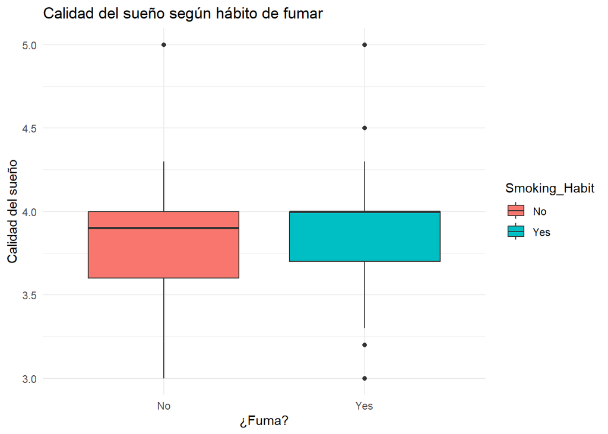

```r
ggplot(df, aes(x = Smoking_Habit, y = Sleep_Quality, fill = Smoking_Habit)) +
  geom_boxplot() +
  labs(title = "Calidad del sueño según hábito de fumar",
       x = "¿Fuma?", y = "Calidad del sueño") +
  theme_minimal()
```

## 6.2. Meditación y Calidad del Sueño

**Hipótesis:**

- H₀: No hay diferencia en la calidad del sueño entre quienes meditan y quienes no.
- H₁: Quienes meditan tienen diferente calidad del sueño.

**Test estadístico (t-test):**

```r
# t-test
t.test(Sleep_Quality ~ Meditation_Practice, data = df)
```

```
##
##  Welch Two Sample t-test
##
## data:  Sleep_Quality by Meditation_Practice
## t = -4.2398, df = 558.25, p-value = 2.618e-05
## alternative hypothesis: true difference in means between group No and group Yes is not equal to 0
## 95 percent confidence interval:
##  -0.24387943 -0.08945391
## sample estimates:
##  mean in group No mean in group Yes
##          3.773577          3.940244
```

**Interpretación:** El p-valor es muy pequeño (p < 0.001), por lo que se rechaza la hipótesis nula. Hay evidencia estadística de que **practicar meditación está asociado a una mejor calidad del sueño.**

**Visualización:**

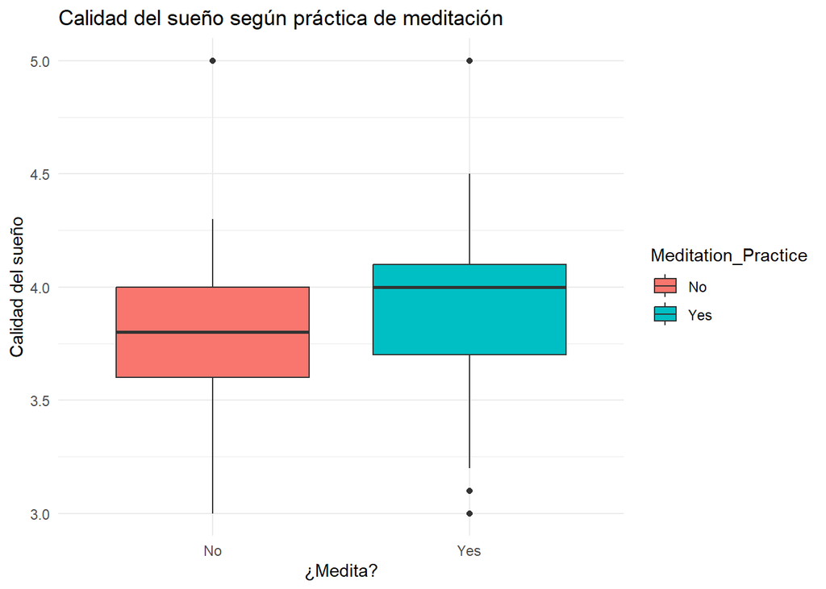

```r
ggplot(df, aes(x = Meditation_Practice, y = Sleep_Quality, fill = Meditation_Practice)) +
  geom_boxplot() +
  labs(title = "Calidad del sueño según práctica de meditación",
       x = "¿Medita?", y = "Calidad del sueño") +
  theme_minimal()
```

## 6.3. Horas de Trabajo y Actividad Física

**Hipótesis:**

- H₀: No hay correlación entre horas de trabajo y actividad física.
- H₁: Existe correlación entre horas de trabajo y actividad física.

**Test estadístico (correlación de Pearson):**

```r
cor.test(df$Work_Hours, df$Physical_Activity, method = "pearson")
```

```
##
##  Pearson's product-moment correlation
##
## data:  df$Work_Hours and df$Physical_Activity
## t = 1.5116, df = 654, p-value = 0.1311
## alternative hypothesis: true correlation is not equal to 0
## 95 percent confidence interval:
##  -0.01762335  0.13494527
## sample estimates:
##        cor
## 0.05900552
```

**Interpretación:** El p-valor es mayor que 0.05, lo que indica que **no hay evidencia suficiente para rechazar la hipótesis nula**. No se encontró una correlación estadísticamente significativa entre las horas de trabajo y la actividad física.

**Visualización:**

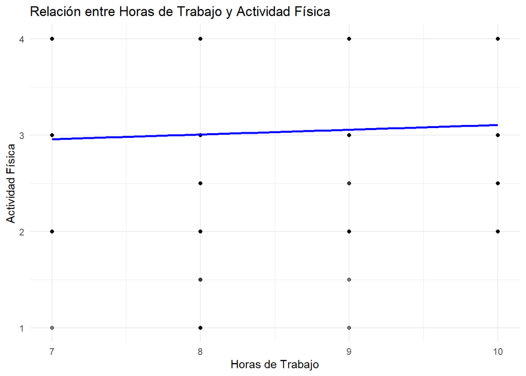

```r
ggplot(df, aes(x = Work_Hours, y = Physical_Activity)) +
  geom_point(alpha = 0.5) +
  geom_smooth(method = "lm", se = FALSE, color = "blue") +
  labs(title = "Relación entre Horas de Trabajo y Actividad Física",
       x = "Horas de Trabajo", y = "Actividad Física") +
  theme_minimal()
```

## 6.4. Azúcar en Sangre y Colesterol

**Hipótesis:**

- H₀: No hay correlación entre el nivel de azúcar en sangre y colesterol.
- H₁: Existe correlación entre el nivel de azúcar en sangre y colesterol.

**Test estadístico (correlación de Pearson):**

```r
cor.test(df$Blood_Sugar_Level, df$Cholesterol_Level, method = "pearson")
```

```
##
##  Pearson's product-moment correlation
##
## data:  df$Blood_Sugar_Level and df$Cholesterol_Level
## t = 60.904, df = 654, p-value < 2.2e-16
## alternative hypothesis: true correlation is not equal to 0
## 95 percent confidence interval:
##  0.9096719 0.9327339
## sample estimates:
##       cor
## 0.9220168
```

**Visualización:**

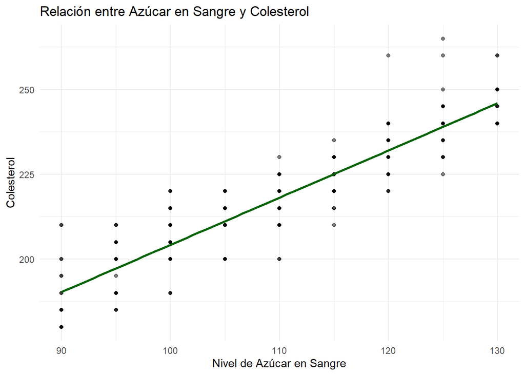

```r
ggplot(df, aes(x = Blood_Sugar_Level, y = Cholesterol_Level)) +
  geom_point(alpha = 0.5) +
  geom_smooth(method = "lm", se = FALSE, color = "darkgreen") +
  labs(title = "Relación entre Azúcar en Sangre y Colesterol",
       x = "Nivel de Azúcar en Sangre", y = "Colesterol") +
  theme_minimal()
```